# Bank Marketing Data Analysis

# 1. Reading Data

```r
# Reading the data
## Training data - Covariates
X_train_SMOTE = read.csv("./DATA/X_train_SMOTE.csv")
## Training data - Response Variable
y_train_SMOTE = read.csv("./DATA/y_train_SMOTE.csv", header = F)
```

# 2. Data Preprocessing

The data we preprocessed in [python notebook](https://github.com/nandishpatel1996/DATA-SCIENCE-PROJECTS/blob/master/BANK%20MARKETING%20DATA/Project_Notebook.ipynb) was suitable for analysis in python. For R we need to convert few dummy variables into factors.

```r
## Job
job_cols <- as.matrix(X_train_SMOTE[7:17])
job_cat <- factor(job_cols %*% 1:ncol(job_cols),
       labels = c("job_admin", colnames(job_cols)))

## Marital status
marital_cols <- as.matrix(X_train_SMOTE[18:19])
marital_cat <- factor(marital_cols %*% 1:ncol(marital_cols),
                      labels = c("marital_divorced", colnames(marital_cols)))

## Education
education_cols <- as.matrix(X_train_SMOTE[20:22])
education_cat <- factor(education_cols %*% 1:ncol(education_cols),
                      labels = c("education_primary", colnames(education_cols)))

## Month
month_cols <- as.matrix(X_train_SMOTE[23:33])
month_cat <- factor(month_cols %*% 1:ncol(month_cols),
                      labels = c("month_apr", colnames(month_cols)))

## Poutcome
poutcome_cols <- as.matrix(X_train_SMOTE[34:36])
poutcome_cat <- factor(poutcome_cols %*% 1:ncol(poutcome_cols),
                        labels = c("poutcome_failure", colnames(poutcome_cols)))

## Contact
contact_cols <- as.matrix(X_train_SMOTE[37:38])
contact_cat <- factor(contact_cols %*% 1:ncol(contact_cols),
                       labels = c("contact_cellular", colnames(contact_cols)))
```

Now let’s create a new dataframe just for our analysis in R.

```r
# Creating a new dataframe
data_R_train <- X_train_SMOTE[1:6]

# Adding the newly created categorical variables to the dataframe
data_R_train["job"] <- factor(gsub("job_", "", job_cat))
data_R_train["marital"] <- factor(gsub("marital_", "", marital_cat))
data_R_train["education"] <- factor(gsub("education_", "", education_cat))
data_R_train["month"] <- factor(gsub("month_", "", month_cat))
data_R_train["poutcome"] <- factor(gsub("poutcome_", "", poutcome_cat))
data_R_train["contact"] <- factor(gsub("contact_", "", contact_cat))

# Adding response variable to the dataframe
data_R_train["subscribed"] <- y_train_SMOTE

# Save the data for future use
write.csv(data_R_train, "./DATA/train_data_R.csv", row.names = F)

# Printing few rows of a dataframe
head(data_R_train)
```

|  | age | balance | day | duration | campaign | pdays | job | marital | education | month | poutcome | contact | subscribed |
| --- | --- | --- | --- | --- | --- | --- | --- | --- | --- | --- | --- | --- | --- |
| 1 | 0.1916100 | 4.30367845 | 0.6238264 | 0.9491276 | -0.5691168 | -0.4118156 | self.employed | married | secondary | nov | unknown | cellular | 1 |
| 2 | -0.4674177 | 0.08613267 | -0.5787325 | -0.8231328 | 0.0759744 | -0.4118156 | management | married | tertiary | jun | unknown | unknown | 0 |
| 3 | 0.6623441 | -0.28349116 | -1.0597561 | -0.5671827 | -0.2465712 | -0.4118156 | technician | married | secondary | may | unknown | cellular | 0 |
| 4 | 0.3799037 | 0.14532630 | -0.8192443 | 0.7940063 | -0.5691168 | -0.4118156 | technician | married | tertiary | jun | unknown | unknown | 0 |
| 5 | -0.6557114 | -0.45333650 | -0.5787325 | 0.2782281 | -0.2465712 | -0.4118156 | management | married | tertiary | aug | unknown | cellular | 0 |
| 6 | 0.4740505 | -0.43012991 | 0.2630587 | -0.6059630 | -0.2465712 | -0.4118156 | self.employed | single | secondary | jul | unknown | cellular | 0 |

After preparing our dataframe, the next step will be modeling of this data mainly of the response variable in terms of predictor variables.

# 3. Data Modeling

Since the response variable `subscribed`(whether user subscribed to a term plan or not) is dichotomous we will use binomial response distribution to model it. Also, few of the covariates are skewed in distribution since GLM doesn’t require the covariates to be normal so the skewness in covariates is acceptable. We will go ahead and carry out various types of tests to check the significance of the covariates.

```r
# Model fitting with all covariates with binomial response distribution and logit link function
glm_1 = glm(subscribed ~ ., family = binomial(), data = data_R_train)

# Printing Summary of the model
summary(glm_1)
```

```
##
## Call:
## glm(formula = subscribed ~ ., family = binomial(), data = data_R_train)
##
## Deviance Residuals:
##     Min       1Q   Median       3Q      Max
## -7.1465  -0.4328  -0.0015   0.4620   3.9102
##
## Coefficients:
##                     Estimate Std. Error z value Pr(>|z|)
## (Intercept)         4.624243   0.080049  57.768  < 2e-16 ***
## age                -0.040348   0.016347  -2.468   0.0136 *
## balance            -0.003977   0.013392  -0.297   0.7665
## day                 0.013137   0.014603   0.900   0.3683
## duration            1.548832   0.016009  96.748  < 2e-16 ***
## campaign           -0.375565   0.021532 -17.442  < 2e-16 ***
## pdays              -0.338013   0.020127 -16.794  < 2e-16 ***
## jobblue.collar     -2.023933   0.044470 -45.512  < 2e-16 ***
## jobentrepreneur    -2.696493   0.107713 -25.034  < 2e-16 ***
## jobhousemaid       -3.236324   0.127218 -25.439  < 2e-16 ***
## jobmanagement      -1.359363   0.045524 -29.860  < 2e-16 ***
## jobretired         -0.952944   0.065955 -14.448  < 2e-16 ***
## jobself.employed   -2.302483   0.089822 -25.634  < 2e-16 ***
## jobservices        -1.884766   0.057955 -32.521  < 2e-16 ***
## jobstudent         -0.360958   0.079573  -4.536 5.73e-06 ***
## jobtechnician      -1.526894   0.042272 -36.120  < 2e-16 ***
## jobunemployed      -2.192284   0.090777 -24.150  < 2e-16 ***
## jobunknown         -1.996680   0.220775  -9.044  < 2e-16 ***
## maritalmarried     -0.677968   0.036937 -18.355  < 2e-16 ***
## maritalsingle      -0.488894   0.043667 -11.196  < 2e-16 ***
## educationsecondary -0.865968   0.038958 -22.228  < 2e-16 ***
## educationtertiary  -0.453882   0.048110  -9.434  < 2e-16 ***
## educationunknown   -1.208723   0.083929 -14.402  < 2e-16 ***
## monthaug           -2.202405   0.044847 -49.109  < 2e-16 ***
## monthdec           -1.419396   0.171829  -8.261  < 2e-16 ***
## monthfeb           -1.783757   0.055488 -32.147  < 2e-16 ***
## monthjan           -3.684969   0.099005 -37.220  < 2e-16 ***
## monthjul           -2.966534   0.048846 -60.733  < 2e-16 ***
## monthjun           -1.029710   0.058743 -17.529  < 2e-16 ***
## monthmar           -0.050617   0.098203  -0.515   0.6063
## monthmay           -2.338375   0.043870 -53.302  < 2e-16 ***
## monthnov           -2.813239   0.054138 -51.964  < 2e-16 ***
## monthoct           -0.672195   0.085406  -7.871 3.53e-15 ***
## monthsep           -0.595043   0.095440  -6.235 4.52e-10 ***
## poutcomeother      -1.017058   0.071753 -14.174  < 2e-16 ***
## poutcomesuccess     1.924716   0.068476  28.108  < 2e-16 ***
## poutcomeunknown    -1.063592   0.057347 -18.547  < 2e-16 ***
## contacttelephone   -0.803158   0.063812 -12.586  < 2e-16 ***
## contactunknown     -2.240853   0.049531 -45.241  < 2e-16 ***
## ---
## Signif. codes:  0 '***' 0.001 '**' 0.01 '*' 0.05 '.' 0.1 ' ' 1
##
## (Dispersion parameter for binomial family taken to be 1)
##
##     Null deviance: 88387  on 63757  degrees of freedom
## Residual deviance: 41641  on 63719  degrees of freedom
## AIC: 41719
##
## Number of Fisher Scoring iterations: 6
```

```r
# Carrying out Type II test to check the significance of the variables as if they were added last in the model
# We are using Anova() from car package
car::Anova(glm_1)
```

|  | LR Chisq | Df | Pr(>Chisq) |
| --- | --- | --- | --- |
| age | 6.090594e+00 | 1 | 1.359034e-02 |
| balance | 8.823028e-02 | 1 | 7.664392e-01 |
| day | 8.094442e-01 | 1 | 3.682846e-01 |
| duration | 1.722399e+04 | 1 | 0.000000e+00 |
| campaign | 3.285972e+02 | 1 | 1.942308e-73 |
| pdays | 2.757931e+02 | 1 | 6.199866e-62 |
| job | 4.138510e+03 | 11 | 0.000000e+00 |
| marital | 3.439337e+02 | 2 | 2.068936e-75 |
| education | 6.119968e+02 | 3 | 2.527046e-132 |
| month | 8.283887e+03 | 11 | 0.000000e+00 |

[output cut: 2 more lines]

By looking at the Anova type II test we can see that the variables `balance`, and `day` are statistically insignificant which means these covariates are not bringing any significant information to the model. We should analyze the added-variable plot to observe the relationship between those covariates and response variable.

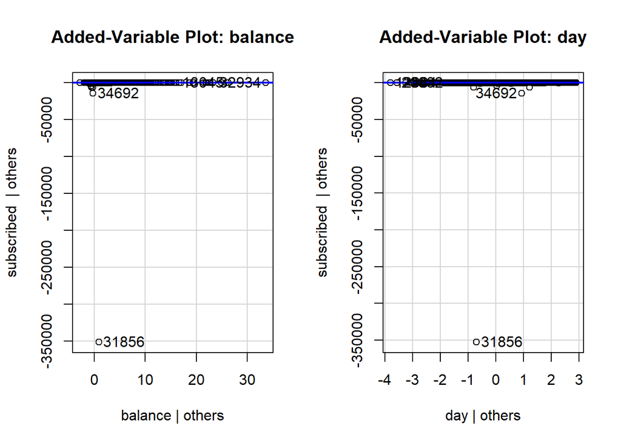

```r
par(mfrow = c(1, 2))
car::avPlot(glm_1, variable = "balance")
car::avPlot(glm_1, variable = "day")
```

By looking at the added-variable plot we can see that there are horizontal lines in both plots which suggests the terms `balance` and `day` are of no use and there is no hint of non-linear relation between these covariates and response variable `subscribed`. So let’s go ahead and remove these covariates from the model and fir the model again.

```r
# Model fitting with all covariates with binomial response distribution and logit link function.
glm_2 = glm(subscribed ~ . - balance - day, family = binomial(), data = data_R_train)

# Printing Summary of the model
summary(glm_2)
```

```
##
## Call:
## glm(formula = subscribed ~ . - balance - day, family = binomial(),
##     data = data_R_train)
##
## Deviance Residuals:
##     Min       1Q   Median       3Q      Max
## -7.1483  -0.4327  -0.0016   0.4617   3.9069
##
## Coefficients:
##                    Estimate Std. Error z value Pr(>|z|)
## (Intercept)         4.62467    0.07998  57.821  < 2e-16 ***
## age                -0.04090    0.01630  -2.510   0.0121 *
## duration            1.54870    0.01601  96.748  < 2e-16 ***
## campaign           -0.37298    0.02134 -17.479  < 2e-16 ***
## pdays              -0.33782    0.02011 -16.798  < 2e-16 ***
## jobblue.collar     -2.02374    0.04446 -45.520  < 2e-16 ***
## jobentrepreneur    -2.69806    0.10773 -25.044  < 2e-16 ***
## jobhousemaid       -3.23499    0.12718 -25.437  < 2e-16 ***
## jobmanagement      -1.35992    0.04552 -29.876  < 2e-16 ***
## jobretired         -0.95163    0.06594 -14.433  < 2e-16 ***
## jobself.employed   -2.30255    0.08980 -25.640  < 2e-16 ***
## jobservices        -1.88495    0.05793 -32.537  < 2e-16 ***
## jobstudent         -0.36196    0.07955  -4.550 5.36e-06 ***
## jobtechnician      -1.52658    0.04227 -36.112  < 2e-16 ***
## jobunemployed      -2.19201    0.09079 -24.143  < 2e-16 ***
## jobunknown         -1.99930    0.22072  -9.058  < 2e-16 ***
## maritalmarried     -0.67915    0.03692 -18.397  < 2e-16 ***
## maritalsingle      -0.48986    0.04364 -11.224  < 2e-16 ***
## educationsecondary -0.86568    0.03895 -22.224  < 2e-16 ***
## educationtertiary  -0.45353    0.04810  -9.429  < 2e-16 ***
## educationunknown   -1.20819    0.08392 -14.397  < 2e-16 ***
## monthaug           -2.20584    0.04457 -49.490  < 2e-16 ***
## monthdec           -1.42445    0.17173  -8.295  < 2e-16 ***
## monthfeb           -1.79699    0.05321 -33.771  < 2e-16 ***
## monthjan           -3.66863    0.09750 -37.627  < 2e-16 ***
## monthjul           -2.96467    0.04869 -60.885  < 2e-16 ***
## monthjun           -1.04491    0.05617 -18.603  < 2e-16 ***
## monthmar           -0.05574    0.09799  -0.569   0.5694
## monthmay           -2.34231    0.04347 -53.877  < 2e-16 ***
## monthnov           -2.81226    0.05407 -52.007  < 2e-16 ***
## monthoct           -0.66533    0.08505  -7.823 5.15e-15 ***
## monthsep           -0.60293    0.09496  -6.349 2.16e-10 ***
## poutcomeother      -1.01543    0.07170 -14.161  < 2e-16 ***
## poutcomesuccess     1.92486    0.06846  28.117  < 2e-16 ***
## poutcomeunknown    -1.06158    0.05728 -18.533  < 2e-16 ***
## contacttelephone   -0.80415    0.06381 -12.602  < 2e-16 ***
## contactunknown     -2.23386    0.04891 -45.672  < 2e-16 ***
## ---
## Signif. codes:  0 '***' 0.001 '**' 0.01 '*' 0.05 '.' 0.1 ' ' 1
##
## (Dispersion parameter for binomial family taken to be 1)
##
##     Null deviance: 88387  on 63757  degrees of freedom
## Residual deviance: 41642  on 63721  degrees of freedom
## AIC: 41716
##
## Number of Fisher Scoring iterations: 6
```

```r
# Carrying out Type II test to check the significance of the variables as if they were added last in the model. We are using Anova() from car package.
car::Anova(glm_2)
```

|  | LR Chisq | Df | Pr(>Chisq) |
| --- | --- | --- | --- |
| age | 6.297323 | 1 | 1.209204e-02 |
| duration | 17230.569633 | 1 | 0.000000e+00 |
| campaign | 331.081733 | 1 | 5.587090e-74 |
| pdays | 275.978881 | 1 | 5.647938e-62 |
| job | 4140.044882 | 11 | 0.000000e+00 |
| marital | 345.478300 | 2 | 9.557411e-76 |
| education | 612.067747 | 3 | 2.439074e-132 |
| month | 8345.007440 | 11 | 0.000000e+00 |
| poutcome | 2711.184882 | 3 | 0.000000e+00 |
| contact | 2480.110490 | 2 | 0.000000e+00 |

As we can see from the above output that all the covariates are significant. We can also see that it has residual deviance of 41642 on 63721 degrees of freedom, so the model is an adequate fit. Now first let’s prepare data for the evaluating the model.

# 4. Data Preparation of Validation dataset

```r
# Validation data
X_valid = read.csv("./DATA/X_valid.csv")
y_valid = read.csv("./DATA/y_valid.csv", header = F)

## Job
job_cols <- as.matrix(X_valid[7:17])
job_cat <- factor(job_cols %*% 1:ncol(job_cols), labels = c("job_admin", colnames(job_cols)))

## Marital status
marital_cols <- as.matrix(X_valid[18:19])
marital_cat <- factor(marital_cols %*% 1:ncol(marital_cols), labels = c("marital_divorced", colnames(marital_cols)))

## Education
education_cols <- as.matrix(X_valid[20:22])
education_cat <- factor(education_cols %*% 1:ncol(education_cols), labels = c("education_primary", colnames(education_cols)))

## Month
month_cols <- as.matrix(X_valid[23:33])
month_cat <- factor(month_cols %*% 1:ncol(month_cols), labels = c("month_apr", colnames(month_cols)))

## Poutcome
poutcome_cols <- as.matrix(X_valid[34:36])
poutcome_cat <- factor(poutcome_cols %*% 1:ncol(poutcome_cols), labels = c("poutcome_failure", colnames(poutcome_cols)))

## Contact
contact_cols <- as.matrix(X_valid[37:38])
contact_cat <- factor(contact_cols %*% 1:ncol(contact_cols), labels = c("contact_cellular", colnames(contact_cols)))

# Creating a new dataframe
data_R_valid <- X_valid[1:6]

# Adding the newly created categorical variables to the dataframe
data_R_valid["job"] <- factor(gsub("job_", "", job_cat))
data_R_valid["marital"] <- factor(gsub("marital_", "", marital_cat))
data_R_valid["education"] <- factor(gsub("education_", "", education_cat))
data_R_valid["month"] <- factor(gsub("month_", "", month_cat))
data_R_valid["poutcome"] <- factor(gsub("poutcome_", "", poutcome_cat))
data_R_valid["contact"] <- factor(gsub("contact_", "", contact_cat))

# Adding response variable to the dataframe
data_R_valid["subscribed"] <- y_valid
```

# 5. Model Evaluation

Let’s use model to make predictions and based on the predictions, let’s assess the model performance.

```r
# Training dataset
## Prediction using the model
glm_2_pred_train = predict.glm(glm_2, newdata = data_R_train[1:12], type = "r")

## Predictions using GLM model
prediction_train = as.factor(ifelse(glm_2_pred_train > 0.5, 1, 0))

## Confusion Matrix
caret::confusionMatrix(reference = as.factor(y_train_SMOTE$V1), data = prediction_train, positive = "1")
```

```
## Confusion Matrix and Statistics
##
##           Reference
## Prediction     0     1
##          0 27684  4102
##          1  4195 27777
##
##                Accuracy : 0.8699
##                  95% CI : (0.8672, 0.8725)
##     No Information Rate : 0.5
##     P-Value [Acc > NIR] : <2e-16
##
##                   Kappa : 0.7397
##
##  Mcnemar's Test P-Value : 0.3125
##
##             Sensitivity : 0.8713
##             Specificity : 0.8684
##          Pos Pred Value : 0.8688
##          Neg Pred Value : 0.8709
##              Prevalence : 0.5000
##          Detection Rate : 0.4357
##    Detection Prevalence : 0.5015
##       Balanced Accuracy : 0.8699
##
##        'Positive' Class : 1
##
```

```r
# Validation dataset
## Prediction using the model
glm_2_pred_valid = predict.glm(glm_2, newdata = data_R_valid[1:12], type = "r")

## Predictions using GLM model
prediction_valid = as.factor(ifelse(glm_2_pred_valid > 0.5, 1, 0))

## Confusion Matrix
caret::confusionMatrix(reference = as.factor(y_valid$V1), data = prediction_valid, positive = "1")
```

```
## Confusion Matrix and Statistics
##
##           Reference
## Prediction    0    1
##          0 3423  152
##          1  609  337
##
##                Accuracy : 0.8317
##                  95% CI : (0.8204, 0.8425)
##     No Information Rate : 0.8918
##     P-Value [Acc > NIR] : 1
##
##                   Kappa : 0.3815
##
##  Mcnemar's Test P-Value : <2e-16
##
##             Sensitivity : 0.68916
##             Specificity : 0.84896
##          Pos Pred Value : 0.35624
##          Neg Pred Value : 0.95748
##              Prevalence : 0.10816
##          Detection Rate : 0.07454
##    Detection Prevalence : 0.20925
##       Balanced Accuracy : 0.76906
##
##        'Positive' Class : 1
##
```

```r
saveRDS(glm_2, "./MODELS/GLM_2.rds")
```